# Pioneer House Residential Life Survey - Student Satisfaction & Interaction Customer Analytics

Batch 9 / Group 8: Muhammad Faizal Bin Ehsan, Tang Wai Wah Serena, Lai Cheng Jun

2026-03-16

#### Use of AI Declaraction:

Portions of this R script, including explanations, data preparation steps, and code examples, were generated with the assistance of OpenAI’s ChatGPT (GPT-5-mini) to support analysis and documentation. All final decisions, interpretations, and data handling were reviewed and executed by the author.

## Load Data

```r
library(pacman)
pacman::p_load(readxl, tidyverse, sentimentr, pROC, caret)

# Load the Pioneer House survey dataset
df <- data.frame(read_excel("../data/phrl_survey.xlsx"))
str(df)
```

```
## 'data.frame':    115 obs. of  27 variables:
##  $ ID                                                       : num  1 2 3 4 5 6 7 8 9 10 ...
##  $ Nationality                                              : chr  "International Student" "Singapore Citizen/PR" "International Student" "International Student" ...
##  $ PCT                                                      : chr  "PCT 5" "PCT 9" "PCT 2" "PCT 5" ...
##  $ Year_of_Study                                            : chr  "Year 1" "Year 2" "Year 4 " "Year 1" ...
##  $ Residential_experience                                   : chr  "The activities in PH have complemented my personal development journey.;" "The activities in PH have complemented my personal development journey.;The activities in PH have promoted grou"| __truncated__ "There are a lot of intere…
##  $ Interaction_with_neighbours                              : chr  "I know most of my neighbours well. ;" "I know most of my neighbours well. ;I enjoy hanging out with my neighbours.;I chat with my neighbours occasionally.;" "I know most of my neighbours well. ;I enjoy hanging out with my neighbo…
##  $ Interaction_with_PH_Residential_Staff_and_Student_Leaders: chr  "I feel engaged by the staff and student leaders in PH.;" "I feel engaged by the staff and student leaders in PH.;I enjoyed interacting and communicating with the staff a"| __truncated__ "I feel engaged by the staff and student le…
##  $ Memorable_residential_experience_in_PH                   : chr  "joining the igs" "Hosting my first IG session, was a fun and memorable experience." "Cooking, night talk, running, every events were memorable" "My memorable residential experience was when we went to West Coast Park with our PCT…
##  $ Overall_satisfaction                                     : num  3 5 5 5 4 4 3 4 3 5 ...
##  $ Interacted_RA                                            : num  1 1 1 1 1 1 1 1 1 1 ...
##  $ RA_Name                                                  : chr  "Valerie Ang En Yu" "Sandrina Agnes Natalie" "Gavin Chiam Xiang Zhe" "Valerie Ang En Yu" ...
##  $ Interaction_with_RA                                      : chr  "House-wide events;" "House-wide events;Activities / events in your cluster;RA visited your room;" "House-wide events;Activities / events in your cluster;Met in common areas;" "Activities / events in your cluster;House-wide events…
##  $ RA_Helpful                                               : chr  "Neutral" "Helpful" "Helpful" "Helpful" ...
##  $ Area_RA_could_improved                                   : chr  "shes friendly and always there to help" "She is very approachable and helpful" "Very responsive and always the first to offer help" "My RA is very friendly. She always smiles at me, approaches me, and chats with me. She makes me …
##  $ Interacted_with_PM                                       : num  1 1 0 1 1 1 0 1 1 1 ...
##  $ PM_Name                                                  : chr  "Javen" "Sidarth" NA "Phoebe and Shivani" ...
##  $ Interaction_with_PM                                      : chr  "Need assistance from PM/CL;Mail collection;" "Activities or events in your cluster/ PCT;Met in common areas;" NA "Activities or events in your cluster/ PCT;Mail collection;Met in common areas;" ...
##  $ PM_Helpful                                               : num  4 5 NA 5 5 5 NA 5 5 3 ...
##  $ Area_PM_could_improved                                   : chr  "he has answered a lot of my questions regarding ph" "hes a great guy" NA "Whenever there are activities organized in Pioneer House, our Cluster PM always brings us together and encourag"| __truncated__ ...
##  $ Sign_up_for_PMP                                          : num  1 0 0 1 0 1 0 0 1 1 ...
##  $ MENTOR.PM.Name.                                          : chr  "Bach Nguyen" NA NA "Leanne" ...
##  $ Area_MENTOR_PM_could_improved                            : chr  "-" NA NA "My peer mentor has done very well in sharing useful experiences about business courses and helping us with ques"| __truncated__ ...
##  $ Interacted_with_SC                                       : num  0 1 1 1 0 1 0 1 1 0 ...
##  $ Interaction_with_SC                                      : chr  NA "Handling matters regarding my IG;" "Enquiring on SC events;Giving ideas about PH;" "Applying for a committee position;" ...
##  $ Overall_experience_with_SC                               : chr  NA "Its fun" "High quality, very well planned" "I really enjoyed the SC events like PHair and PHamigos. They were fun and helped me make new friends. The event"| __truncated__ ...
##  $ Events_you_wish_from_Student_Council                     : chr  "-" "block shirt/ lanyards/ merch to have more ph/block identity" "I am already very satisfied with what they have done so far" "I wish to see more welfare activities during exam week to help residents relax and destress." ...
##  $ Overall_Suggestion                                       : chr  "welfare packs should include stuff you can hsng up" "my door cannot lock" "We can have PH wide welfare items, for example during exam period， give out acai to our residents, and ask res"| __truncated__ "I would like to see more c…
```

## Prepare Data

```r
# Define the text columns
text_columns <- c(
  "Residential_experience",
  "Interaction_with_neighbours",
  "Interaction_with_PH_Residential_Staff_and_Student_Leaders",
  "Memorable_residential_experience_in_PH",
  "Interaction_with_RA",
  "Area_RA_could_improved",
  "Interaction_with_PM",
  "Area_PM_could_improved",
  "Area_MENTOR_PM_could_improved",
  "Interaction_with_SC",
  "Overall_experience_with_SC",
  "Events_you_wish_from_Student_Council",
  "Overall_Suggestion"
)

# Create a copy of df for EDA/modeling
df_model <- df

# Convert interacted columns to Yes/No
df_model <- df_model %>%
  mutate(
    Interacted_RA = ifelse(Interacted_RA == 1, "Yes", "No"),
    Interacted_with_PM = ifelse(Interacted_with_PM == 1, "Yes", "No"),
    Interacted_with_SC = ifelse(Interacted_with_SC == 1, "Yes", "No")
  )

# Convert text columns to weighted sentiment scores
for (col in text_columns) {

  # Sentiment score
  sentiment_result <- sentiment(df_model[[col]]) %>%
    group_by(element_id) %>%
    summarise(sentiment = mean(sentiment)) %>%
    arrange(element_id)

  # Text length
  text_length <- nchar(df_model[[col]])

  # Weighted score: sentiment * log(1 + length)
  weighted_score <- sentiment_result$sentiment * log1p(text_length)

  # Add as new column
  new_col <- paste0(col, "_score")
  df_model[[new_col]] <- weighted_score

  # Remove original text column
  df_model[[col]] <- NULL
}

# Create highest satisfaction column, 5 = yes, 4-0 = no
df_model$Highest_satisfaction <- ifelse(df_model$Overall_satisfaction == 5, "Yes", "No")

# Remove overall_satisfaction column from df_model
df_model <- df_model %>% select(-Overall_satisfaction)

# Update RA_helpful based on keyword "helpful" to yes or no
df_model$RA_Helpful <- ifelse(
  grepl("helpful", df_model$RA_Helpful, ignore.case = TRUE),
  "Yes",
  "No"
)

# Update PM_helpful based on rating 4 or 5
df_model$PM_Helpful <- ifelse(
  df_model$PM_Helpful %in% 4:5,
  "Yes",
  "No"
)

# Replace all null in df_model with 0 because we want to use all data due to small dataset
df_model[is.na(df_model)] <- 0

# Replace PM_Name from 0 to Not applicable
df_model$PM_Name[df_model$PM_Name == 0] <- "Not applicable"

# Replace Mentor.PM.Name from 0 to Not applicable
df_model$MENTOR.PM.Name.[df_model$MENTOR.PM.Name. == 0] <- "Not applicable"
```

## EDA

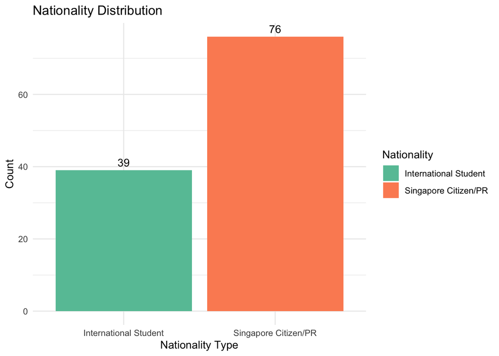

```r
# Check nationality
ggplot(df_model, aes(x = Nationality, fill = Nationality)) +
  geom_bar() +
  geom_text(aes(label = after_stat(count)), stat = "count", vjust = -0.5) +
  labs(
    title = "Nationality Distribution",
    x = "Nationality Type",
    y = "Count"
  ) +
  scale_fill_brewer(palette = "Set2") +
  theme_minimal()
```

#### 76 students (66%) are Singapore Citizens/PR and 39 (34%) are International Students, suggesting nationality may influence differences in residential satisfaction and experiences.

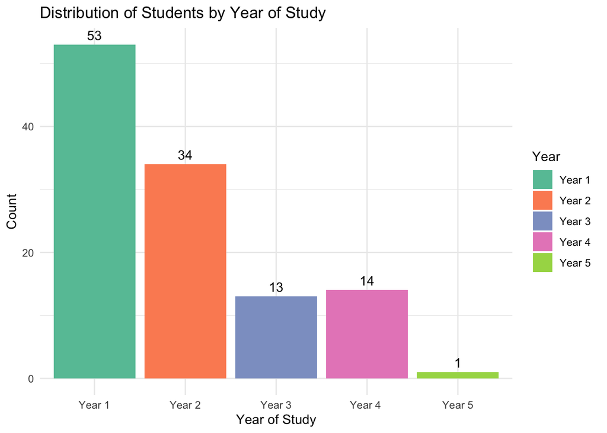

```r
# Check year of study
ggplot(df_model, aes(x = Year_of_Study, fill = Year_of_Study)) +
  geom_bar() +
  geom_text(aes(label = after_stat(count)), stat = "count", vjust = -0.5) +
  labs(
    title = "Distribution of Students by Year of Study",
    x = "Year of Study",
    y = "Count"
  ) +
  scale_fill_brewer(palette = "Set2", name = "Year") +
  theme_minimal()
```

#### The distribution of students by year is uneven (Year 1: 53, Year 2: 34, Year 3: 13, Year 4: 14, Year 5: 1), suggesting that there may not be enough data for senior years to reliably capture their satisfaction patterns.

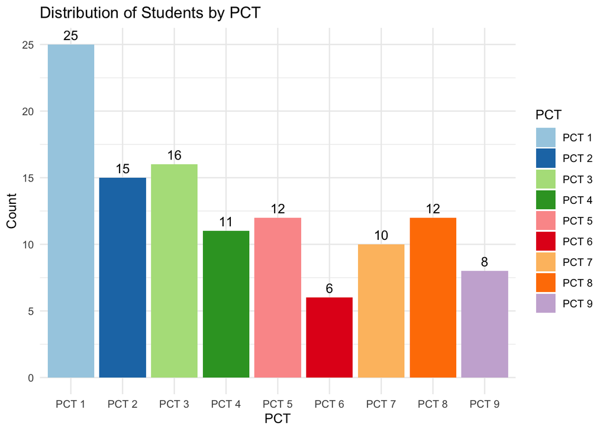

```r
# Check PCT
ggplot(df_model, aes(x = PCT, fill = PCT)) +
  geom_bar() +
  geom_text(aes(label = after_stat(count)), stat = "count", vjust = -0.5) +
  labs(
    title = "Distribution of Students by PCT",
    x = "PCT",
    y = "Count"
  ) +
  scale_fill_brewer(palette = "Paired", name = "PCT") +
  theme_minimal()
```

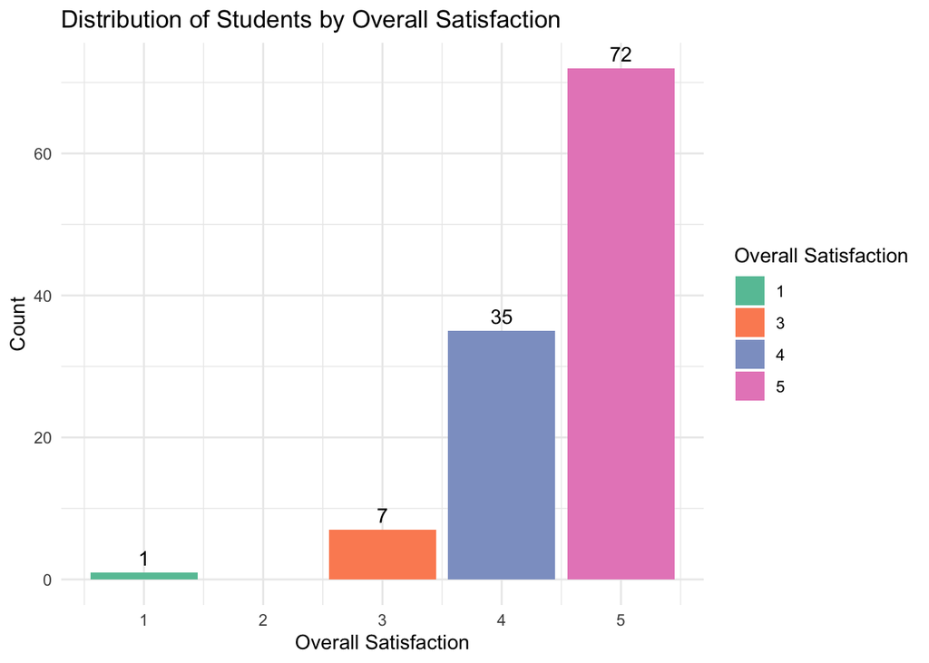

```r
# Check overall satisfaction
ggplot(df, aes(x = Overall_satisfaction, fill = as.factor(Overall_satisfaction))) +
  geom_bar() +
  geom_text(aes(label = after_stat(count)), stat = "count", vjust = -0.5) +
  labs(
    title = "Distribution of Students by Overall Satisfaction",
    x = "Overall Satisfaction",
    y = "Count"
  ) +
  scale_fill_brewer(palette = "Set2", name = "Overall Satisfaction") +
  theme_minimal()
```

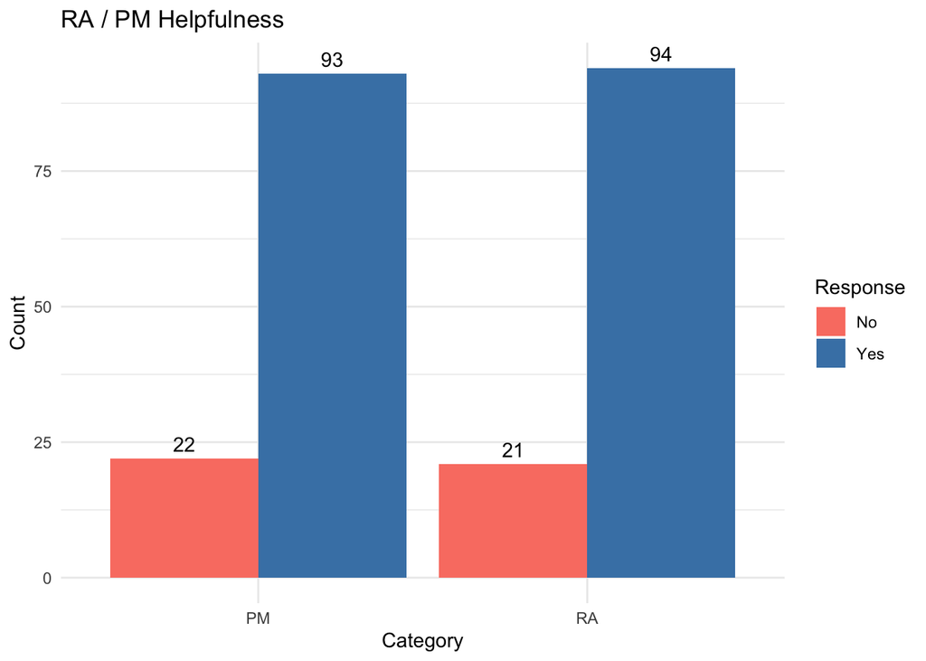

```r
# Check ra / pm helpfulness
# Count Yes/No for each interaction
helpful_count <- df_model %>%
  summarise(
    RA_No = sum(RA_Helpful == "No"),
    RA_Yes = sum(RA_Helpful == "Yes"),
    PM_No = sum(PM_Helpful == "No"),
    PM_Yes = sum(PM_Helpful == "Yes"),
  ) %>%
  pivot_longer(everything(),
               names_to = c("category", "response"),
               names_sep = "_",
               values_to = "count")

ggplot(helpful_count, aes(x = category, y = count, fill = response)) +
  geom_col(position = "dodge") +
  geom_text(aes(label = count), position = position_dodge(width = 0.9), vjust = -0.5) +
  labs(
    title = "RA / PM Helpfulness",
    x = "Category",
    y = "Count"
  ) +
  scale_fill_manual(values = c("No" = "salmon", "Yes" = "steelblue"), name = "Response") +
  theme_minimal()
```

#### Most students perceive their RA (94/115, 82%) and PM (93/115, 81%) as helpful, with relatively few negative responses (RA: 21, 18%; PM: 22, 19%), suggesting helpfulness is a strong positive factor.

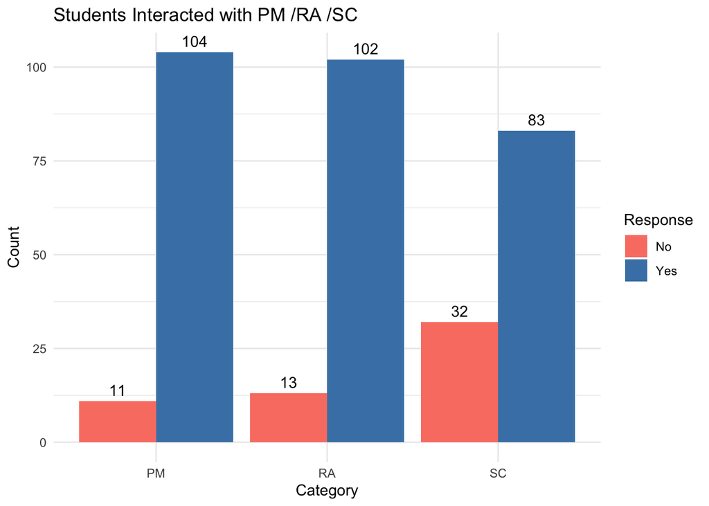

```r
# Check interacted with pm / sc / ra
# Count Yes/No for each interaction
interacted_count <- df_model %>%
  summarise(
    RA_No = sum(Interacted_RA == "No"),
    RA_Yes = sum(Interacted_RA == "Yes"),
    PM_No = sum(Interacted_with_PM == "No"),
    PM_Yes = sum(Interacted_with_PM == "Yes"),
    SC_No = sum(Interacted_with_SC == "No"),
    SC_Yes = sum(Interacted_with_SC == "Yes")
  ) %>%
  pivot_longer(everything(),
               names_to = c("category", "response"),
               names_sep = "_",
               values_to = "count")

ggplot(interacted_count, aes(x = category, y = count, fill = response)) +
  geom_col(position = "dodge") +
  geom_text(aes(label = count), position = position_dodge(width = 0.9), vjust = -0.5) +
  labs(
    title = "Students Interacted with PM /RA /SC",
    x = "Category",
    y = "Count"
  ) +
  scale_fill_manual(values = c("No" = "salmon", "Yes" = "steelblue"), name = "Response") +
  theme_minimal()
```

#### Most students interacted with their PM (104/115, 90%) and RA (102/115, 89%), while SC engagement was lower (83/115, 72%), suggesting frequency of contact may influence satisfaction.

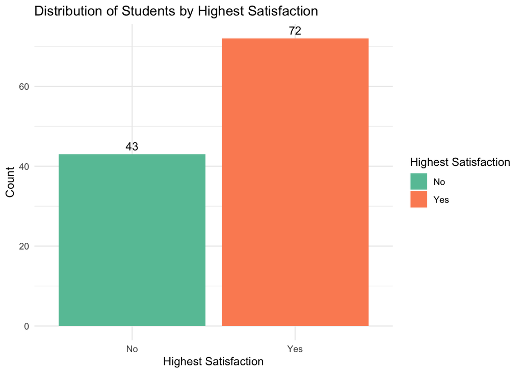

```r
# Check highest satisfaction, 5 = yes, 4-0 = no
ggplot(df_model, aes(x = Highest_satisfaction, fill = Highest_satisfaction)) +
  geom_bar() +
  geom_text(aes(label = after_stat(count)), stat = "count", vjust = -0.5) +
  labs(
    title = "Distribution of Students by Highest Satisfaction",
    x = "Highest Satisfaction",
    y = "Count"
  ) +
  scale_fill_brewer(palette = "Set2", name = "Highest Satisfaction") +
  theme_minimal()
```

#### Binarising Overall Satisfaction into “Highest Satisfaction” suggests a clear classification target, with 63% of students as Yes” (score 5) and 37% as “No” (≤4), suitable for modeling.

## Propensity Modelling

```r
# Change variables in character format to factor
df_model <- df_model %>%
  mutate_if(is.character,as.factor)

# Check for duplicated rows
sum(duplicated(df_model))
```

```
## [1] 0
```

```r
# Check the dataset size
NROW(df_model); NCOL(df_model)
```

```
## [1] 115
```

```
## [1] 27
```

```r
# Return rows with missing values in any variable
NROW(df_model[rowSums(is.na(df_model)) > 0, ])
```

```
## [1] 0
```

```r
# Create a logistic regression propensity model to predict
# 'Highest_satisfaction'. Use a 70:30 train:test split. Use set.seed(0). Be sure to rebalance
# the training dataset if appropriate to do so.
set.seed(0)
train_set <- createDataPartition(df_model$Highest_satisfaction, p = 0.7,list = FALSE) # Select 70% of the df_model
train_imbalance <- df_model[train_set, ] # 70%
test <- df_model[-train_set, ] # 30%

# We will now rebalance the training set.
summary(train_imbalance$Highest_satisfaction)
```

```
##  No Yes
##  31  51
```

```r
# Undersample the dominant class (that is, 'yes') to get the same subsample size
set.seed(0)  # for reproducibility
yes_indices <- sample(which(train_imbalance$Highest_satisfaction == "Yes"), 31)
no_indices <- sample(which(train_imbalance$Highest_satisfaction == "No"), 31)

# Combine the sampled indices
partition <- c(yes_indices, no_indices)

# Create the balanced dataset from the train_imbalance dataframe
train <- train_imbalance[partition,]

# Confirm the number of instances from each response classes
summary(train$Highest_satisfaction) # 'No' = 31, 'Yes' = 31
```

```
##  No Yes
##  31  31
```

```r
train$Highest_satisfaction <- factor(train$Highest_satisfaction, levels = c("No", "Yes"))

# Model 1 - Use all appropriate variables.
# Initial model (m0) - using all variables
m0 <- glm(Highest_satisfaction ~ .,
          data = train,
          family = binomial)

summary(m0)
```

```
##
## Call:
## glm(formula = Highest_satisfaction ~ ., family = binomial, data = train)
##
## Coefficients: (48 not defined because of singularities)
##                                                                   Estimate
## (Intercept)                                                     -7.970e+01
## ID                                                              -4.955e-07
## NationalitySingapore Citizen/PR                                 -5.313e+01
## PCTPCT 2                                                        -1.588e-04
## PCTPCT 3                                                         1.063e+02
## PCTPCT 4                                                        -5.313e+01
## PCTPCT 5                                                         1.063e+02
## PCTPCT 6                                                         1.594e+02
## PCTPCT 7                                                         1.063e+02
## PCTPCT 8                                                         3.308e-05
## PCTPCT 9                                                         5.313e+01
## Year_of_StudyYear 2                                             -3.112e-05
## Year_of_StudyYear 3                                              5.313e+01
## Year_of_StudyYear 4                                             -1.050e-04
## Interacted_RAYes                                                -1.594e+02
## RA_NameAnthony Goh Yunfeng                                       5.313e+01
## RA_NameGabrielle Tay Qiao Yi                                            NA
## RA_NameGavin Chiam Xiang Zhe                                            NA
## RA_NameHannah Elizabeth Varughese                                       NA
## RA_NameI'm not sure                                              2.657e+02
## RA_NameLiang Jingying                                            1.063e+02
## RA_NameRyan Tan Jia Le                                          -1.819e-04
## RA_NameSandrina Agnes Natalie                                           NA
## RA_NameTan Zhi Shen                                              5.313e+01
## RA_NameValerie Ang En Yu                                                NA
## RA_HelpfulYes                                                    1.063e+02
## Interacted_with_PMYes                                            1.063e+02
## PM_NameChua Zhi Qun                                             -1.063e+02
## PM_NameEdison                                                   -1.063e+02
## PM_NameEunice                                                   -1.063e+02
## PM_Nameeunice gwee                                              -1.266e-06
## PM_NameEunice Gwee Wan Xin                                      -1.063e+02
## PM_NameFabio                                                    -1.063e+02
## PM_NameGarv                                                      1.063e+02
```

[output cut: 402 more lines]

```
## Interaction_with_PM_score                                             NA
## Area_PM_could_improved_score                                          NA
## Area_MENTOR_PM_could_improved_score                                   NA
## Interaction_with_SC_score                                             NA
## Overall_experience_with_SC_score                                      NA
## Events_you_wish_from_Student_Council_score                            NA
## Overall_Suggestion_score                                              NA
##
## (Dispersion parameter for binomial family taken to be 1)
##
##     Null deviance: 8.595e+01  on 61  degrees of freedom
## Residual deviance: 3.597e-10  on  0  degrees of freedom
## AIC: 124
##
## Number of Fisher Scoring iterations: 25
```

```r
# Check factor levels
str(df_model)
```

```
## 'data.frame':    115 obs. of  27 variables:
##  $ ID                                                             : num  1 2 3 4 5 6 7 8 9 10 ...
##  $ Nationality                                                    : Factor w/ 2 levels "International Student",..: 1 2 1 1 2 1 2 1 2 2 ...
##  $ PCT                                                            : Factor w/ 9 levels "PCT 1","PCT 2",..: 5 9 2 5 2 4 3 3 3 1 ...
##  $ Year_of_Study                                                  : Factor w/ 5 levels "Year 1","Year 2",..: 1 2 4 1 3 1 2 4 1 1 ...
##  $ Interacted_RA                                                  : Factor w/ 2 levels "No","Yes": 2 2 2 2 2 2 2 2 2 2 ...
##  $ RA_Name                                                        : Factor w/ 11 levels "0","Anthony Goh Yunfeng",..: 11 9 4 11 4 8 2 2 2 7 ...
##  $ RA_Helpful                                                     : Factor w/ 2 levels "No","Yes": 1 2 2 2 2 2 2 2 2 2 ...
##  $ Interacted_with_PM                                             : Factor w/ 2 levels "No","Yes": 2 2 1 2 2 2 1 2 2 2 ...
##  $ PM_Name                                                        : Factor w/ 71 levels "Alden","Annabelle (not sure what her full name is)",..: 24 53 43 45 35 1 43 30 16 18 ...
##  $ PM_Helpful                                                     : Factor w/ 2 levels "No","Yes": 2 2 1 2 2 2 1 2 2 1 ...
##  $ Sign_up_for_PMP                                                : num  1 0 0 1 0 1 0 0 1 1 ...
##  $ MENTOR.PM.Name.                                                : Factor w/ 41 levels "Alden","Alden Ho",..: 4 22 22 19 22 31 22 22 18 12 ...
##  $ Interacted_with_SC                                             : Factor w/ 2 levels "No","Yes": 1 2 2 2 1 2 1 2 2 1 ...
##  $ Residential_experience_score                                   : num  1.9 3.37 3.37 3.2 3.37 ...
##  $ Interaction_with_neighbours_score                              : num  0.983 1.626 1.626 1.182 1.992 ...
##  $ Interaction_with_PH_Residential_Staff_and_Student_Leaders_score: num  0.728 3.355 3.355 3.355 0 ...
##  $ Memorable_residential_experience_in_PH_score                   : num  0 1.57 1.29 2.78 1.05 ...
##  $ Interaction_with_RA_score                                      : num  0 0 0 0 0 ...
##  $ Area_RA_could_improved_score                                   : num  1.04 4.64 1.9 1.61 5.06 ...
##  $ Interaction_with_PM_score                                      : num  1.14 0 0 0 0 ...
##  $ Area_PM_could_improved_score                                   : num  0 0.693 0 2.769 3.319 ...
##  $ Area_MENTOR_PM_could_improved_score                            : num  0 0 0 3.96 0 ...
##  $ Interaction_with_SC_score                                      : num  0 0 0 0 0 0 0 0 0 0 ...
##  $ Overall_experience_with_SC_score                               : num  0 1.1 3.78 3.48 0 ...
##  $ Events_you_wish_from_Student_Council_score                     : num  0 -1.45 2.127 -2.266 -0.439 ...
##  $ Overall_Suggestion_score                                       : num  0.786 0 2.244 3.554 1.459 ...
##  $ Highest_satisfaction                                           : Factor w/ 2 levels "No","Yes": 1 2 2 2 1 1 1 1 1 2 ...
```

```r
# Next model (m1) - remove ID, RA_Name, PM_Name, MENTOR.PM.Name.- PCT - Year_of Study; >5 factor levels
# Excluded high-cardinality variables to avoid overfitting.
m1 <- glm(Highest_satisfaction ~ . - ID - RA_Name - PM_Name - MENTOR.PM.Name. - PCT - Year_of_Study,
  data = train,
  family = binomial)

summary(m1)
```

```
##
## Call:
## glm(formula = Highest_satisfaction ~ . - ID - RA_Name - PM_Name -
##     MENTOR.PM.Name. - PCT - Year_of_Study, family = binomial,
##     data = train)
##
## Coefficients:
##                                                                   Estimate
## (Intercept)                                                       -4.47937
## NationalitySingapore Citizen/PR                                    0.55169
## Interacted_RAYes                                                  -0.29449
## RA_HelpfulYes                                                      0.53959
## Interacted_with_PMYes                                            -18.14002
## PM_HelpfulYes                                                     19.19083
## Sign_up_for_PMP                                                   -2.58149
## Interacted_with_SCYes                                              0.32249
## Residential_experience_score                                      -0.57443
## Interaction_with_neighbours_score                                  1.43250
## Interaction_with_PH_Residential_Staff_and_Student_Leaders_score    1.47187
## Memorable_residential_experience_in_PH_score                       0.62577
## Interaction_with_RA_score                                         -0.29128
## Area_RA_could_improved_score                                       0.02717
## Interaction_with_PM_score                                          0.44693
## Area_PM_could_improved_score                                      -0.04672
## Area_MENTOR_PM_could_improved_score                                0.20289
## Interaction_with_SC_score                                          1.38040
## Overall_experience_with_SC_score                                  -0.66935
## Events_you_wish_from_Student_Council_score                        -0.15925
## Overall_Suggestion_score                                          -0.40500
##                                                                 Std. Error
## (Intercept)                                                        2.31804
## NationalitySingapore Citizen/PR                                    0.96957
## Interacted_RAYes                                                   2.17618
## RA_HelpfulYes                                                      1.62633
## Interacted_with_PMYes                                           2475.33737
## PM_HelpfulYes                                                   2475.33714
## Sign_up_for_PMP                                                    1.28940
## Interacted_with_SCYes                                              1.12339
## Residential_experience_score                                       0.69438
## Interaction_with_neighbours_score                                  0.81954
```

[output cut: 50 more lines]

```
## Area_MENTOR_PM_could_improved_score                               0.6431
## Interaction_with_SC_score                                         0.4117
## Overall_experience_with_SC_score                                  0.1274
## Events_you_wish_from_Student_Council_score                        0.6636
## Overall_Suggestion_score                                          0.3795
## ---
## Signif. codes:  0 '***' 0.001 '**' 0.01 '*' 0.05 '.' 0.1 ' ' 1
##
## (Dispersion parameter for binomial family taken to be 1)
##
##     Null deviance: 85.950  on 61  degrees of freedom
## Residual deviance: 50.546  on 41  degrees of freedom
## AIC: 92.546
##
## Number of Fisher Scoring iterations: 17
```

```r
# Next model (m2) - remove ID, RA_Name, PM_Name, MENTOR.PM.Name.- PCT - Year_of Study - Sign_up_for_PMP
# Excluded "Sign_up_for_PMP" assuming programme sign-up may not directly affect satisfaction.
m2 <- glm(Highest_satisfaction ~ . - ID - RA_Name - PM_Name - MENTOR.PM.Name. - PCT - Year_of_Study - Sign_up_for_PMP,
  data = train,
  family = binomial)

summary(m2)
```

```
##
## Call:
## glm(formula = Highest_satisfaction ~ . - ID - RA_Name - PM_Name -
##     MENTOR.PM.Name. - PCT - Year_of_Study - Sign_up_for_PMP,
##     family = binomial, data = train)
##
## Coefficients:
##                                                                   Estimate
## (Intercept)                                                       -4.55409
## NationalitySingapore Citizen/PR                                   -0.09125
## Interacted_RAYes                                                  -0.01053
## RA_HelpfulYes                                                      0.19016
## Interacted_with_PMYes                                            -17.72174
## PM_HelpfulYes                                                     18.64370
## Interacted_with_SCYes                                              0.83153
## Residential_experience_score                                      -0.17311
## Interaction_with_neighbours_score                                  1.38081
## Interaction_with_PH_Residential_Staff_and_Student_Leaders_score    1.06358
## Memorable_residential_experience_in_PH_score                       0.94751
## Interaction_with_RA_score                                         -0.09893
## Area_RA_could_improved_score                                       0.06986
## Interaction_with_PM_score                                         -0.30425
## Area_PM_could_improved_score                                      -0.27766
## Area_MENTOR_PM_could_improved_score                               -0.36377
## Interaction_with_SC_score                                          1.58807
## Overall_experience_with_SC_score                                  -0.76201
## Events_you_wish_from_Student_Council_score                        -0.08853
## Overall_Suggestion_score                                          -0.47401
##                                                                 Std. Error
## (Intercept)                                                        2.30642
## NationalitySingapore Citizen/PR                                    0.81657
## Interacted_RAYes                                                   1.96079
## RA_HelpfulYes                                                      1.50068
## Interacted_with_PMYes                                           2481.18482
## PM_HelpfulYes                                                   2481.18460
## Interacted_with_SCYes                                              1.02524
## Residential_experience_score                                       0.57411
## Interaction_with_neighbours_score                                  0.73638
## Interaction_with_PH_Residential_Staff_and_Student_Leaders_score    0.52784
## Memorable_residential_experience_in_PH_score                       0.42758
```

[output cut: 46 more lines]

```
## Area_MENTOR_PM_could_improved_score                               0.2376
## Interaction_with_SC_score                                         0.3217
## Overall_experience_with_SC_score                                  0.0669 .
## Events_you_wish_from_Student_Council_score                        0.7881
## Overall_Suggestion_score                                          0.2427
## ---
## Signif. codes:  0 '***' 0.001 '**' 0.01 '*' 0.05 '.' 0.1 ' ' 1
##
## (Dispersion parameter for binomial family taken to be 1)
##
##     Null deviance: 85.950  on 61  degrees of freedom
## Residual deviance: 55.304  on 42  degrees of freedom
## AIC: 95.304
##
## Number of Fisher Scoring iterations: 17
```

## Confusion Matrix & Propensity Score (m1)

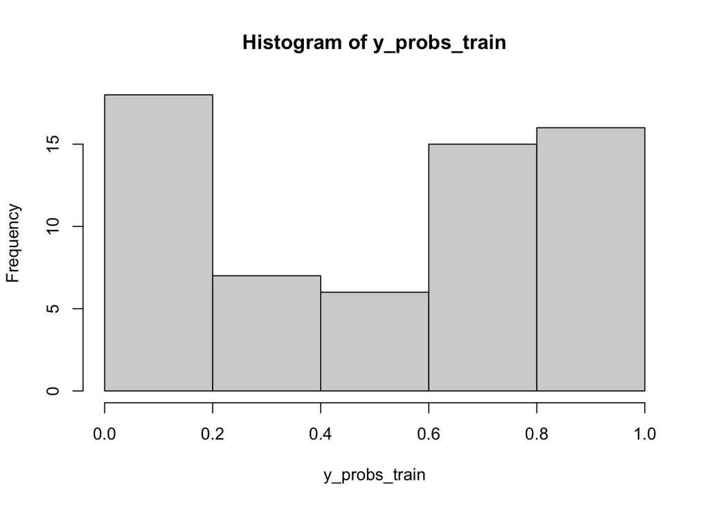

```r
# Create confusion matrices for the 'test' set and the 'train' set,
# assuming cut-off/threshold of 50%.

# Find the propensity score of each student
y_probs_train <- predict(m1, newdata = train, type = "response")
hist(y_probs_train)
```

```r
# Add propensity score to each student
train$propensity_score <- y_probs_train

# View the first few rows of students' propensity score
head(train[, c("ID", "propensity_score")])
```

```
##    ID propensity_score
## 41 41        0.9936593
## 18 18        0.9787873
## 91 91        0.6276331
## 2   2        0.9732817
## 79 79        0.9122410
## 61 61        0.7039264
```

```r
# Predict whether each student would have highest satisfaction using the propensity model, using threshold of 50%.
y_pred_train <- factor(ifelse(y_probs_train > 0.5, "Yes", "No"), levels = c("No", "Yes"))
y_true_train <- train$Highest_satisfaction

# Create the confusion matrix and evaluate how good the model is
confusionMatrix(data = y_pred_train, reference = y_true_train, mode = "everything", positive = "Yes")
```

```
## Confusion Matrix and Statistics
##
##           Reference
## Prediction No Yes
##        No  24   3
##        Yes  7  28
##
##                Accuracy : 0.8387
##                  95% CI : (0.7233, 0.9198)
##     No Information Rate : 0.5
##     P-Value [Acc > NIR] : 2.857e-08
##
##                   Kappa : 0.6774
##
##  Mcnemar's Test P-Value : 0.3428
##
##             Sensitivity : 0.9032
##             Specificity : 0.7742
##          Pos Pred Value : 0.8000
##          Neg Pred Value : 0.8889
##               Precision : 0.8000
##                  Recall : 0.9032
##                      F1 : 0.8485
##              Prevalence : 0.5000
##          Detection Rate : 0.4516
##    Detection Prevalence : 0.5645
##       Balanced Accuracy : 0.8387
##
##        'Positive' Class : Yes
##
```

#### m1 produced propensity scores close to 1, indicating a higher likelihood that a student reported the highest satisfaction.

#### m1 also shows strong sensitivity (0.903), indicating that it performs well in correctly identifying students who reported the highest satisfaction. The specificity (0.774) value indicates a reasonable ability to correctly identify students who did not report the highest satisfaction.

## ROC Curve (m1)

```r
# Create ROC object
roc_obj <- roc(train$Highest_satisfaction, predict(m1, type = "response"))
```

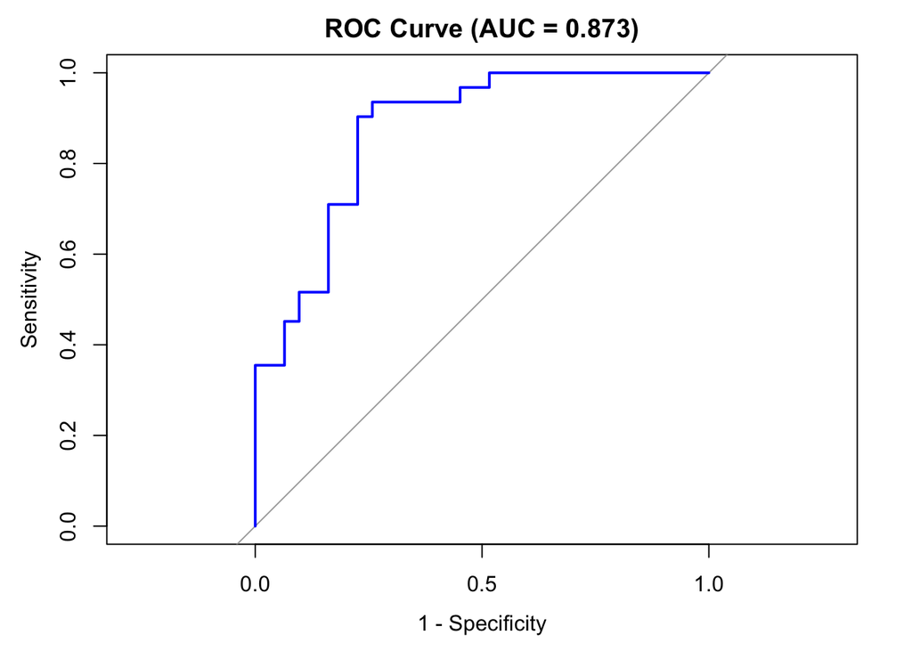

```r
# Plot the ROC curve
plot(
  roc_obj,
  col = "blue",
  main = paste0("ROC Curve (AUC = ", round(auc(roc_obj), 3), ")"),
  legacy.axes = TRUE
)
```

#### AUC = 0.873 indicates that the m1 has strong ability to differentiate between students with highest satisfaction and those without.

## Confusion Matrix & Propensity Score (m2)

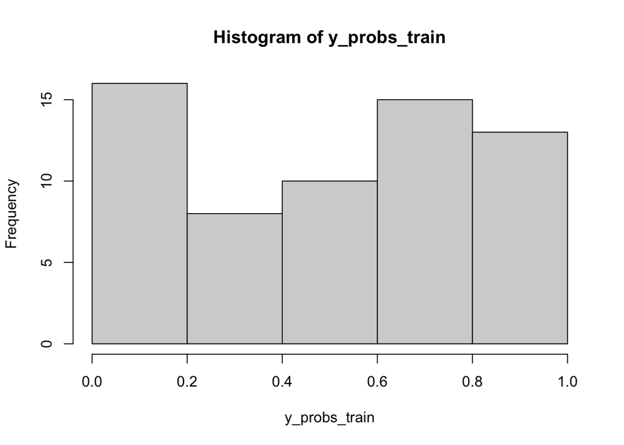

```r
# Create confusion matrices for the 'test' set and the 'train' set,
# assuming cut-off/threshold of 50%.

# Find the propensity score of each student
y_probs_train <- predict(m2, newdata = train, type = "response")
hist(y_probs_train)
```

```r
# Add propensity score to each student
train$propensity_score <- y_probs_train

# View the first few rows of students' propensity score
head(train[, c("ID", "propensity_score")])
```

```
##    ID propensity_score
## 41 41        0.9948292
## 18 18        0.9496354
## 91 91        0.7323826
## 2   2        0.9686150
## 79 79        0.8639029
## 61 61        0.5112289
```

```r
# Predict whether each student would have highest satisfaction using the propensity model, using threshold of 50%.
y_pred_train <- factor(ifelse(y_probs_train > 0.5, "Yes", "No"), levels = c("No", "Yes"))
y_true_train <- train$Highest_satisfaction

# Create the confusion matrix and evaluate how good the model is
confusionMatrix(data = y_pred_train, reference = y_true_train, mode = "everything", positive = "Yes")
```

```
## Confusion Matrix and Statistics
##
##           Reference
## Prediction No Yes
##        No  24   4
##        Yes  7  27
##
##                Accuracy : 0.8226
##                  95% CI : (0.7047, 0.908)
##     No Information Rate : 0.5
##     P-Value [Acc > NIR] : 1.388e-07
##
##                   Kappa : 0.6452
##
##  Mcnemar's Test P-Value : 0.5465
##
##             Sensitivity : 0.8710
##             Specificity : 0.7742
##          Pos Pred Value : 0.7941
##          Neg Pred Value : 0.8571
##               Precision : 0.7941
##                  Recall : 0.8710
##                      F1 : 0.8308
##              Prevalence : 0.5000
##          Detection Rate : 0.4355
##    Detection Prevalence : 0.5484
##       Balanced Accuracy : 0.8226
##
##        'Positive' Class : Yes
##
```

#### m2 produced propensity scores close to 1 for students predicted to have the highest satisfaction, indicating a high likelihood of reporting highest satisfaction.

#### m2 shows good sensitivity (0.871), meaning it correctly identifies most students who reported the highest satisfaction. Its specificity (0.774) indicates a reasonable ability to correctly identify students who did not report the highest satisfaction.

## ROC Curve (m2)

```r
# Create ROC object
roc_obj <- roc(train$Highest_satisfaction, predict(m2, type = "response"))
```

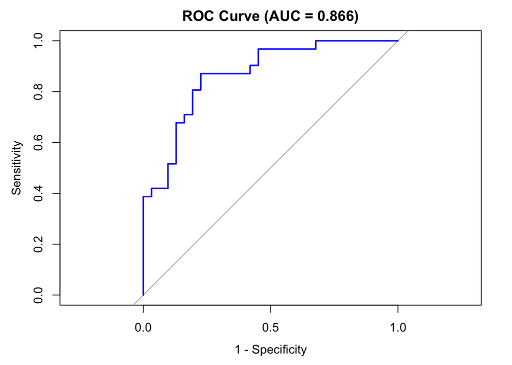

```r
# Plot the ROC curve
plot(
  roc_obj,
  col = "blue",
  main = paste0("ROC Curve (AUC = ", round(auc(roc_obj), 3), ")"),
  legacy.axes = TRUE
)
```

#### AUC of 0.866 indicates the m2 has a strong ability to distinguish highly satisfied students, though slightly lower than M1.

## Conclusion

#### Future iterations could incorporate more survey rounds, additional interaction variables, or alternative models to improve both accuracy and generalisability beyond this initial logistic regression framework.